# JACIE Cumulative Outcomes Report

2025 Annual Report - Rolling Cohort Analysis

Author

HSCT Program Quality Indicators

Published

January 23, 2026

**NoteAI-Generated Report with Rolling Cohort Methodology**

# Executive Summary

## Reporting Period and Methodology

**Reporting Period:** Calendar Year 2025 (January 1 - December 31, 2025)

**Methodology:** Cumulative Rolling Cohort Analysis following JACIE Italian guidelines

**ImportantCumulative Rolling Cohort Methodology**

This report uses **cumulative rolling cohort analysis** as specified by JACIE Italy. For each quarter and timepoint, we calculate outcomes for ALL patients who reached that milestone during the cumulative period from Q1 through that quarter.

**Key principle**: Results should be **cumulative and monotonically increasing** - the percentage at 100 days should be ≥ 30 days, and 365 days should be ≥ 100 days, since we’re looking at the same patients plus those who reach later milestones.

This provides mature outcome data since patients have had sufficient follow-up time.

## Key Findings Summary

### Overall Mortality (All Patients) - Cumulative Rolling Cohort

Table 1: Overall Cumulative Mortality - Rolling Cohort Analysis

| Timepoint | Cohort Size | Deaths | Mortality Rate |
| --- | --- | --- | --- |
| 30 days | 30 | 0 | 0% (0/30) |
| 100 days | 29 | 1 | 3.4% (1/29) |
| 365 days | 20 | 7 | 35% (7/20) |

**NoteUnderstanding Cohort Sizes**

Note that cohort sizes **differ** across timepoints because each represents a different observation period:

- **30-day cohort**: Patients whose 30-day milestone occurred Jan 1 - Nov 30, 2025 (N = 30)
- **100-day cohort**: Patients whose 100-day milestone occurred Jan 1 - Sep 30, 2025 (N = 29)
- **365-day cohort**: Patients whose 365-day milestone occurred Jan 1, 2024 - Dec 31, 2025 (N = 20)

The mortality percentages are cumulative and should generally increase at later timepoints (30d ≤ 100d ≤ 365d) as cumulative mortality accrues over time.

### Mortality by Cause: TRM, NRM, and RRM

Table 2: Cumulative Mortality Breakdown by Cause (Overall = TRM + NRM + RRM)

| Timepoint | Overall Mortality | TRM | NRM | RRM |
| --- | --- | --- | --- | --- |
| 30 days | 0% (0/30) | 0% (0/30) | 0% (0/30) | 0% (0/30) |
| 100 days | 3.4% (1/29) | 0% (0/29) | 3.4% (1/29) | 0% (0/29) |
| 365 days | 35% (7/20) | 15% (3/20) | 10% (2/20) | 10% (2/20) |

**TipUnderstanding Mortality Categories**

**TRM (Treatment-Related Mortality)** includes deaths directly related to the transplant procedure and immediate complications.

**NRM (Non-Relapse Mortality)** includes deaths from:

- Infection
- GVHD complications
- Organ toxicity
- Other transplant-related complications (not classified as TRM)

**RRM (Relapse-Related Mortality)** includes deaths from disease progression or relapse.

At 365 days: **TRM = 15%**, **NRM = 10%**, and **RRM = 10%**

# Detailed Results

## 1. Overall Mortality Analysis

### 1.1 Mortality at Key Timepoints by Cause

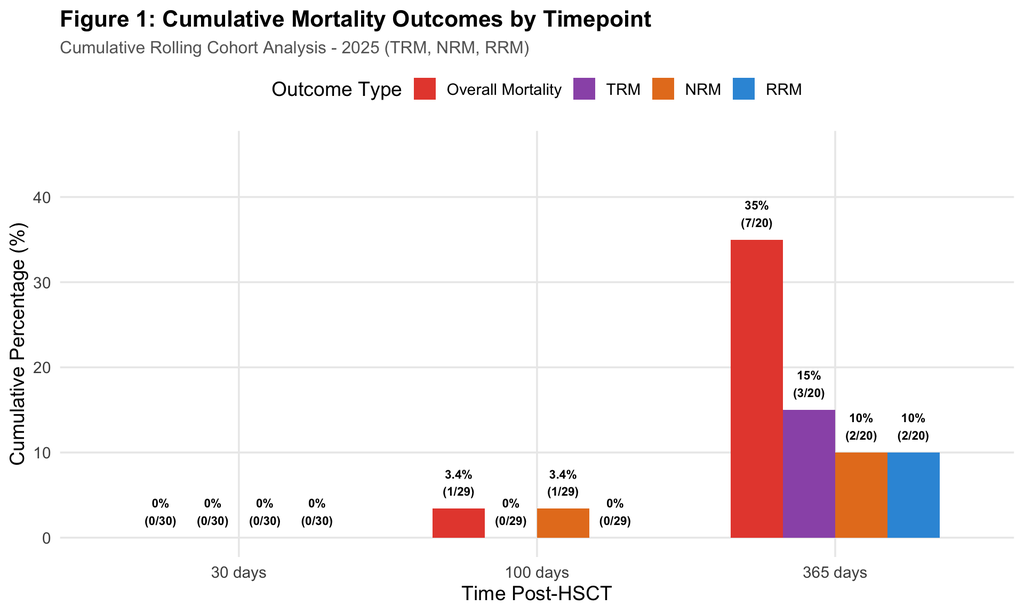

### 1.2 Mortality by Disease Status at Transplant

Table 3: Cumulative Mortality by Disease Status at HSCT

| Group | Timepoint | Cohort Size | Deaths | Mortality Rate |
| --- | --- | --- | --- | --- |
| **Complete Remission** |  |  |  |  |
| Complete Remission | 30 days | 23 | 0 | 0% (0/23) |
| Complete Remission | 100 days | 16 | 0 | 0% (0/16) |
| Complete Remission | 365 days | 11 | 2 | 18.2% (2/11) |
| **Not in Complete Remission** |  |  |  |  |
| Not in Complete Remission | 30 days | 7 | 0 | 0% (0/7) |
| Not in Complete Remission | 100 days | 13 | 1 | 7.7% (1/13) |
| Not in Complete Remission | 365 days | 9 | 5 | 55.6% (5/9) |

**WarningDisease Status Impact**

**Complete Remission patients**: 365-day mortality = 18.2%  
**Not in Complete Remission**: 365-day mortality = 55.6%

Achieving complete remission before transplant is associated with better outcomes.

## 2. Non-Relapse Mortality (NRM)

### 2.1 NRM by Timepoint

Table 4: Cumulative Non-Relapse Mortality (NRM)

| Timepoint | Cohort Size | NRM Events | NRM Rate |
| --- | --- | --- | --- |
| 30 days | 30 | 0 | 0% (0/30) |
| 100 days | 29 | 1 | 3.4% (1/29) |
| 365 days | 20 | 2 | 10% (2/20) |

**ImportantNRM Analysis**

**Definition**: NRM represents deaths from transplant-related complications, NOT disease progression.

- **30-day NRM**: 0% - Early transplant complications
- **100-day NRM**: 3.4% - Standard early NRM window
- **365-day NRM**: 10% - Cumulative NRM including late complications

NRM accounts for **29%** of all deaths at 365 days.

### 2.2 NRM by Disease Status

Table 5: Non-Relapse Mortality by Disease Status

| Group | Timepoint | Cohort Size | NRM Events | NRM Rate |
| --- | --- | --- | --- | --- |
| **Overall** |  |  |  |  |
| Overall | 30 days | 30 | 0 | 0% (0/30) |
| Overall | 100 days | 29 | 1 | 3.4% (1/29) |
| Overall | 365 days | 20 | 2 | 10% (2/20) |
| **Complete Remission** |  |  |  |  |
| Complete Remission | 30 days | 23 | 0 | 0% (0/23) |
| Complete Remission | 100 days | 16 | 0 | 0% (0/16) |
| Complete Remission | 365 days | 11 | 1 | 9.1% (1/11) |
| **Not in Complete Remission** |  |  |  |  |
| Not in Complete Remission | 30 days | 7 | 0 | 0% (0/7) |
| Not in Complete Remission | 100 days | 13 | 1 | 7.7% (1/13) |
| Not in Complete Remission | 365 days | 9 | 1 | 11.1% (1/9) |

### 2.3 NRM Causes Breakdown

Table 6: Breakdown of NRM by Specific Cause (365-day cohort)

| Cause of NRM | N Events | Percentage |
| --- | --- | --- |
| Other | 2 | 2 (100%) |

## 2.4 TRM (Treatment-Related Mortality)

### 2.4.1 TRM by Timepoint

Table 6A: Cumulative Treatment-Related Mortality (TRM)

| Timepoint | Cohort Size | TRM Events | TRM Rate |
| --- | --- | --- | --- |
| 30 days | 30 | 0 | 0% (0/30) |
| 100 days | 29 | 0 | 0% (0/29) |
| 365 days | 20 | 3 | 15% (3/20) |

**ImportantTRM Analysis**

**Definition**: TRM represents deaths specifically from treatment-related complications (distinct from NRM and relapse).

- **30-day TRM**: 0%
- **100-day TRM**: 0%
- **365-day TRM**: 15%

TRM accounts for **43%** of all deaths at 365 days.

### 2.4.2 TRM by Disease Status

Table 6B: Treatment-Related Mortality by Disease Status

| Group | Timepoint | Cohort Size | TRM Events | TRM Rate |
| --- | --- | --- | --- | --- |
| **Overall** |  |  |  |  |
| Overall | 30 days | 30 | 0 | 0% (0/30) |
| Overall | 100 days | 29 | 0 | 0% (0/29) |
| Overall | 365 days | 20 | 3 | 15% (3/20) |
| **Complete Remission** |  |  |  |  |
| Complete Remission | 30 days | 23 | 0 | 0% (0/23) |
| Complete Remission | 100 days | 16 | 0 | 0% (0/16) |
| Complete Remission | 365 days | 11 | 1 | 9.1% (1/11) |
| **Not in Complete Remission** |  |  |  |  |
| Not in Complete Remission | 30 days | 7 | 0 | 0% (0/7) |
| Not in Complete Remission | 100 days | 13 | 0 | 0% (0/13) |
| Not in Complete Remission | 365 days | 9 | 2 | 22.2% (2/9) |

## 3. Relapse-Related Mortality (RRM)

Table 7: Cumulative Relapse-Related Mortality (RRM)

| Timepoint | Cohort Size | RRM Deaths | RRM Rate |
| --- | --- | --- | --- |
| 30 days | 30 | 0 | 0% (0/30) |
| 100 days | 29 | 0 | 0% (0/29) |
| 365 days | 20 | 2 | 10% (2/20) |

### 3.1 RRM by Disease Status

Table 8: Relapse-Related Mortality (RRM) by Disease Status

| Group | Timepoint | Cohort Size | RRM Deaths | RRM Rate |
| --- | --- | --- | --- | --- |
| **Overall** |  |  |  |  |
| Overall | 30 days | 30 | 0 | 0% (0/30) |
| Overall | 100 days | 29 | 0 | 0% (0/29) |
| Overall | 365 days | 20 | 2 | 10% (2/20) |
| **Complete Remission** |  |  |  |  |
| Complete Remission | 30 days | 23 | 0 | 0% (0/23) |
| Complete Remission | 100 days | 16 | 0 | 0% (0/16) |
| Complete Remission | 365 days | 11 | 0 | 0% (0/11) |
| **Not in Complete Remission** |  |  |  |  |
| Not in Complete Remission | 30 days | 7 | 0 | 0% (0/7) |
| Not in Complete Remission | 100 days | 13 | 0 | 0% (0/13) |
| Not in Complete Remission | 365 days | 9 | 2 | 22.2% (2/9) |

**NoteRRM Summary**

- **365-day RRM**: 10%
- RRM accounts for **29%** of all deaths at 365 days
- Not in CR patients show higher RRM (22.2%) vs CR patients (0%)

**WarningLate Relapse Deaths (After 365 Days)**

**Important Note:** The 365-day rolling cohort includes ** 20 patients** whose 365-day milestone fell during the reporting period. Of these:

- ** 2 patients** died from relapse **within 365 days** post-HSCT (included in 365-day RRM rate above)
- ** 1 additional patient(s)** died from relapse **after 365 days** post-HSCT:
  - Patient GF60: Death at day **428** (63 days after 365-day milestone)

**These late deaths are correctly EXCLUDED from the 365-day mortality analysis** as they occurred beyond the 365-day timepoint. They would be captured in longer-term follow-up analyses (e.g., 2-year or 3-year mortality).

[output not shown]

## 5. Comprehensive Outcomes by Donor Type

Table 11: Comprehensive Outcomes by Donor Type

| Donor Type | 365-Day Mortality | NRM at 365 Days | Acute GVHD II-IV |
| --- | --- | --- | --- |
| Sibling HLA-identical | 0% (0/2) | 0% (0/2) | 0% (0/3) |
| Haploidentical | 50% (6/12) | 16.7% (2/12) | 33.3% (4/12) |
| MUD | 20% (1/5) | 0% (0/5) | 9.1% (1/11) |
| MMUD | 0% (0/1) | 0% (0/1) | 33.3% (1/3) |

## 6. Mortality Outcomes by Donor Type

### 6.1 Overall Mortality by Donor Type (All Timepoints)

Table 13: Overall Mortality by Donor Type Across All Timepoints

| Donor Type | Timepoint | Cohort Size | Deaths | Mortality Rate |
| --- | --- | --- | --- | --- |
| **Sibling HLA-identical** |  |  |  |  |
| Sibling HLA-identical | 30 days | 3 | 0 | 0% (0/3) |
| Sibling HLA-identical | 100 days | 3 | 0 | 0% (0/3) |
| Sibling HLA-identical | 365 days | 2 | 0 | 0% (0/2) |
| **Haploidentical** |  |  |  |  |
| Haploidentical | 30 days | 9 | 0 | 0% (0/9) |
| Haploidentical | 100 days | 12 | 1 | 8.3% (1/12) |
| Haploidentical | 365 days | 12 | 6 | 50% (6/12) |
| **MUD** |  |  |  |  |
| MUD | 30 days | 12 | 0 | 0% (0/12) |
| MUD | 100 days | 11 | 0 | 0% (0/11) |
| MUD | 365 days | 5 | 1 | 20% (1/5) |
| MMUD | 30 days | 6 | 0 | 0% (0/6) |
| MMUD | 100 days | 3 | 0 | 0% (0/3) |
| MMUD | 365 days | 1 | 0 | 0% (0/1) |

### 6.2 NRM by Donor Type (All Timepoints)

Table 14: Non-Relapse Mortality by Donor Type Across All Timepoints

| Donor Type | Timepoint | Cohort Size | NRM Events | NRM Rate |
| --- | --- | --- | --- | --- |
| **Sibling HLA-identical** |  |  |  |  |
| Sibling HLA-identical | 30 days | 3 | 0 | 0% (0/3) |
| Sibling HLA-identical | 100 days | 3 | 0 | 0% (0/3) |
| Sibling HLA-identical | 365 days | 2 | 0 | 0% (0/2) |
| **Haploidentical** |  |  |  |  |
| Haploidentical | 30 days | 9 | 0 | 0% (0/9) |
| Haploidentical | 100 days | 12 | 1 | 8.3% (1/12) |
| Haploidentical | 365 days | 12 | 2 | 16.7% (2/12) |
| **MUD** |  |  |  |  |
| MUD | 30 days | 12 | 0 | 0% (0/12) |
| MUD | 100 days | 11 | 0 | 0% (0/11) |
| MUD | 365 days | 5 | 0 | 0% (0/5) |
| MMUD | 30 days | 6 | 0 | 0% (0/6) |
| MMUD | 100 days | 3 | 0 | 0% (0/3) |
| MMUD | 365 days | 1 | 0 | 0% (0/1) |

### 6.3 Relapse Mortality by Donor Type (All Timepoints)

Table 15: Relapse Mortality by Donor Type Across All Timepoints

| Donor Type | Timepoint | Cohort Size | Relapse Deaths | Relapse Rate |
| --- | --- | --- | --- | --- |
| **Sibling HLA-identical** |  |  |  |  |
| Sibling HLA-identical | 30 days | 3 | 0 | 0% (0/3) |
| Sibling HLA-identical | 100 days | 3 | 0 | 0% (0/3) |
| Sibling HLA-identical | 365 days | 2 | 0 | 0% (0/2) |
| **Haploidentical** |  |  |  |  |
| Haploidentical | 30 days | 9 | 0 | 0% (0/9) |
| Haploidentical | 100 days | 12 | 0 | 0% (0/12) |
| Haploidentical | 365 days | 12 | 1 | 8.3% (1/12) |
| **MUD** |  |  |  |  |
| MUD | 30 days | 12 | 0 | 0% (0/12) |
| MUD | 100 days | 11 | 0 | 0% (0/11) |
| MUD | 365 days | 5 | 1 | 20% (1/5) |
| MMUD | 30 days | 6 | 0 | 0% (0/6) |
| MMUD | 100 days | 3 | 0 | 0% (0/3) |
| MMUD | 365 days | 1 | 0 | 0% (0/1) |

### 6.4 TRM by Donor Type (All Timepoints)

Table 15A: Treatment-Related Mortality by Donor Type Across All Timepoints

| Donor Type | Timepoint | Cohort Size | TRM Events | TRM Rate |
| --- | --- | --- | --- | --- |
| **Sibling HLA-identical** |  |  |  |  |
| Sibling HLA-identical | 30 days | 3 | 0 | 0% (0/3) |
| Sibling HLA-identical | 100 days | 3 | 0 | 0% (0/3) |
| Sibling HLA-identical | 365 days | 2 | 0 | 0% (0/2) |
| **Haploidentical** |  |  |  |  |
| Haploidentical | 30 days | 9 | 0 | 0% (0/9) |
| Haploidentical | 100 days | 12 | 0 | 0% (0/12) |
| Haploidentical | 365 days | 12 | 3 | 25% (3/12) |
| **MUD** |  |  |  |  |
| MUD | 30 days | 12 | 0 | 0% (0/12) |
| MUD | 100 days | 11 | 0 | 0% (0/11) |
| MUD | 365 days | 5 | 0 | 0% (0/5) |
| MMUD | 30 days | 6 | 0 | 0% (0/6) |
| MMUD | 100 days | 3 | 0 | 0% (0/3) |
| MMUD | 365 days | 1 | 0 | 0% (0/1) |

## 7. Combined Stratification: Donor Type × Disease Status

### 7.1 Overall Mortality by Donor Type and CR Status (All Timepoints)

Table 16: Overall Mortality by Donor Type and Disease Status (30, 100, 365 days)

| CR Status | Donor Type | Timepoint | N | Deaths | Mortality Rate (n/N %) |
| --- | --- | --- | --- | --- | --- |
| Complete Remission | Sibling HLA-identical | 30 days | 1 | 0 | 0% (0/1) |
| Complete Remission | Sibling HLA-identical | 100 days | 1 | 0 | 0% (0/1) |
| Complete Remission | Sibling HLA-identical | 365 days | 2 | 0 | 0% (0/2) |
| Complete Remission | Haploidentical | 30 days | 7 | 0 | 0% (0/7) |
| Complete Remission | Haploidentical | 100 days | 5 | 0 | 0% (0/5) |
| Complete Remission | Haploidentical | 365 days | 5 | 2 | 40% (2/5) |
| Complete Remission | MUD | 30 days | 10 | 0 | 0% (0/10) |
| Complete Remission | MUD | 100 days | 8 | 0 | 0% (0/8) |
| Complete Remission | MUD | 365 days | 3 | 0 | 0% (0/3) |
| Complete Remission | MMUD | 30 days | 5 | 0 | 0% (0/5) |
| Complete Remission | MMUD | 100 days | 2 | 0 | 0% (0/2) |
| Complete Remission | MMUD | 365 days | 1 | 0 | 0% (0/1) |
| Not in Complete Remission | Sibling HLA-identical | 30 days | 2 | 0 | 0% (0/2) |
| Not in Complete Remission | Sibling HLA-identical | 100 days | 2 | 0 | 0% (0/2) |
| Not in Complete Remission | Sibling HLA-identical | 365 days | 0 | NA | NA% (NA/0) |
| Not in Complete Remission | Haploidentical | 30 days | 2 | 0 | 0% (0/2) |
| Not in Complete Remission | Haploidentical | 100 days | 7 | 1 | 14.3% (1/7) |
| Not in Complete Remission | Haploidentical | 365 days | 7 | 4 | 57.1% (4/7) |
| Not in Complete Remission | MUD | 30 days | 2 | 0 | 0% (0/2) |
| Not in Complete Remission | MUD | 100 days | 3 | 0 | 0% (0/3) |
| Not in Complete Remission | MUD | 365 days | 2 | 1 | 50% (1/2) |
| Not in Complete Remission | MMUD | 30 days | 1 | 0 | 0% (0/1) |
| Not in Complete Remission | MMUD | 100 days | 1 | 0 | 0% (0/1) |
| Not in Complete Remission | MMUD | 365 days | 0 | NA | NA% (NA/0) |

### 7.2 NRM by Donor Type and CR Status (All Timepoints)

Table 17: NRM by Donor Type and Disease Status (30, 100, 365 days)

| CR Status | Donor Type | Timepoint | N | NRM Events | NRM Rate (n/N %) |
| --- | --- | --- | --- | --- | --- |
| Complete Remission | Sibling HLA-identical | 30 days | 1 | 0 | 0% (0/1) |
| Complete Remission | Sibling HLA-identical | 100 days | 1 | 0 | 0% (0/1) |
| Complete Remission | Sibling HLA-identical | 365 days | 2 | 0 | 0% (0/2) |
| Complete Remission | Haploidentical | 30 days | 7 | 0 | 0% (0/7) |
| Complete Remission | Haploidentical | 100 days | 5 | 0 | 0% (0/5) |
| Complete Remission | Haploidentical | 365 days | 5 | 1 | 20% (1/5) |
| Complete Remission | MUD | 30 days | 10 | 0 | 0% (0/10) |
| Complete Remission | MUD | 100 days | 8 | 0 | 0% (0/8) |
| Complete Remission | MUD | 365 days | 3 | 0 | 0% (0/3) |
| Complete Remission | MMUD | 30 days | 5 | 0 | 0% (0/5) |
| Complete Remission | MMUD | 100 days | 2 | 0 | 0% (0/2) |
| Complete Remission | MMUD | 365 days | 1 | 0 | 0% (0/1) |
| Not in Complete Remission | Sibling HLA-identical | 30 days | 2 | 0 | 0% (0/2) |
| Not in Complete Remission | Sibling HLA-identical | 100 days | 2 | 0 | 0% (0/2) |
| Not in Complete Remission | Sibling HLA-identical | 365 days | 0 | NA | NA% (NA/0) |
| Not in Complete Remission | Haploidentical | 30 days | 2 | 0 | 0% (0/2) |
| Not in Complete Remission | Haploidentical | 100 days | 7 | 1 | 14.3% (1/7) |
| Not in Complete Remission | Haploidentical | 365 days | 7 | 1 | 14.3% (1/7) |
| Not in Complete Remission | MUD | 30 days | 2 | 0 | 0% (0/2) |
| Not in Complete Remission | MUD | 100 days | 3 | 0 | 0% (0/3) |
| Not in Complete Remission | MUD | 365 days | 2 | 0 | 0% (0/2) |
| Not in Complete Remission | MMUD | 30 days | 1 | 0 | 0% (0/1) |
| Not in Complete Remission | MMUD | 100 days | 1 | 0 | 0% (0/1) |
| Not in Complete Remission | MMUD | 365 days | 0 | NA | NA% (NA/0) |

### 7.3 Relapse Mortality by Donor Type and CR Status (All Timepoints)

Table 18: Relapse Mortality by Donor Type and Disease Status (30, 100, 365 days)

| CR Status | Donor Type | Timepoint | N | Relapse Deaths | Relapse Rate (n/N %) |
| --- | --- | --- | --- | --- | --- |
| Complete Remission | Sibling HLA-identical | 30 days | 1 | 0 | 0% (0/1) |
| Complete Remission | Sibling HLA-identical | 100 days | 1 | 0 | 0% (0/1) |
| Complete Remission | Sibling HLA-identical | 365 days | 2 | 0 | 0% (0/2) |
| Complete Remission | Haploidentical | 30 days | 7 | 0 | 0% (0/7) |
| Complete Remission | Haploidentical | 100 days | 5 | 0 | 0% (0/5) |
| Complete Remission | Haploidentical | 365 days | 5 | 0 | 0% (0/5) |
| Complete Remission | MUD | 30 days | 10 | 0 | 0% (0/10) |
| Complete Remission | MUD | 100 days | 8 | 0 | 0% (0/8) |
| Complete Remission | MUD | 365 days | 3 | 0 | 0% (0/3) |
| Complete Remission | MMUD | 30 days | 5 | 0 | 0% (0/5) |
| Complete Remission | MMUD | 100 days | 2 | 0 | 0% (0/2) |
| Complete Remission | MMUD | 365 days | 1 | 0 | 0% (0/1) |
| Not in Complete Remission | Sibling HLA-identical | 30 days | 2 | 0 | 0% (0/2) |
| Not in Complete Remission | Sibling HLA-identical | 100 days | 2 | 0 | 0% (0/2) |
| Not in Complete Remission | Sibling HLA-identical | 365 days | 0 | NA | NA% (NA/0) |
| Not in Complete Remission | Haploidentical | 30 days | 2 | 0 | 0% (0/2) |
| Not in Complete Remission | Haploidentical | 100 days | 7 | 0 | 0% (0/7) |
| Not in Complete Remission | Haploidentical | 365 days | 7 | 1 | 14.3% (1/7) |
| Not in Complete Remission | MUD | 30 days | 2 | 0 | 0% (0/2) |
| Not in Complete Remission | MUD | 100 days | 3 | 0 | 0% (0/3) |
| Not in Complete Remission | MUD | 365 days | 2 | 1 | 50% (1/2) |
| Not in Complete Remission | MMUD | 30 days | 1 | 0 | 0% (0/1) |
| Not in Complete Remission | MMUD | 100 days | 1 | 0 | 0% (0/1) |
| Not in Complete Remission | MMUD | 365 days | 0 | NA | NA% (NA/0) |

### 7.4 TRM by Donor Type and CR Status (All Timepoints)

Table 17A: TRM by Donor Type and Disease Status (30, 100, 365 days)

| CR Status | Donor Type | Timepoint | N | TRM Events | TRM Rate (n/N %) |
| --- | --- | --- | --- | --- | --- |
| Complete Remission | Sibling HLA-identical | 30 days | 1 | 0 | 0% (0/1) |
| Complete Remission | Sibling HLA-identical | 100 days | 1 | 0 | 0% (0/1) |
| Complete Remission | Sibling HLA-identical | 365 days | 2 | 0 | 0% (0/2) |
| Complete Remission | Haploidentical | 30 days | 7 | 0 | 0% (0/7) |
| Complete Remission | Haploidentical | 100 days | 5 | 0 | 0% (0/5) |
| Complete Remission | Haploidentical | 365 days | 5 | 1 | 20% (1/5) |
| Complete Remission | MUD | 30 days | 10 | 0 | 0% (0/10) |
| Complete Remission | MUD | 100 days | 8 | 0 | 0% (0/8) |
| Complete Remission | MUD | 365 days | 3 | 0 | 0% (0/3) |
| Complete Remission | MMUD | 30 days | 5 | 0 | 0% (0/5) |
| Complete Remission | MMUD | 100 days | 2 | 0 | 0% (0/2) |
| Complete Remission | MMUD | 365 days | 1 | 0 | 0% (0/1) |
| Not in Complete Remission | Sibling HLA-identical | 30 days | 2 | 0 | 0% (0/2) |
| Not in Complete Remission | Sibling HLA-identical | 100 days | 2 | 0 | 0% (0/2) |
| Not in Complete Remission | Sibling HLA-identical | 365 days | 0 | NA | NA% (NA/0) |
| Not in Complete Remission | Haploidentical | 30 days | 2 | 0 | 0% (0/2) |
| Not in Complete Remission | Haploidentical | 100 days | 7 | 0 | 0% (0/7) |
| Not in Complete Remission | Haploidentical | 365 days | 7 | 2 | 28.6% (2/7) |
| Not in Complete Remission | MUD | 30 days | 2 | 0 | 0% (0/2) |
| Not in Complete Remission | MUD | 100 days | 3 | 0 | 0% (0/3) |
| Not in Complete Remission | MUD | 365 days | 2 | 0 | 0% (0/2) |
| Not in Complete Remission | MMUD | 30 days | 1 | 0 | 0% (0/1) |
| Not in Complete Remission | MMUD | 100 days | 1 | 0 | 0% (0/1) |
| Not in Complete Remission | MMUD | 365 days | 0 | NA | NA% (NA/0) |

### 7.5 Acute GVHD by Donor Type and CR Status (100 days)

Table 19: 100-Day Acute GVHD II-IV by Donor Type and Disease Status

| Disease Status | Donor Type | Cohort Size | Events | AGVHD II-IV Rate |
| --- | --- | --- | --- | --- |
| **Complete Remission** |  |  |  |  |
| Complete Remission | Sibling HLA-identical | 1 | 0 | 0% (0/1) |
| Complete Remission | Haploidentical | 5 | 2 | 40% (2/5) |
| Complete Remission | MUD | 8 | 1 | 12.5% (1/8) |
| Complete Remission | MMUD | 2 | 1 | 50% (1/2) |
| **Not in Complete Remission** |  |  |  |  |
| Not in Complete Remission | Sibling HLA-identical | 2 | 0 | 0% (0/2) |
| Not in Complete Remission | Haploidentical | 7 | 2 | 28.6% (2/7) |
| Not in Complete Remission | MUD | 3 | 0 | 0% (0/3) |
| Not in Complete Remission | MMUD | 1 | 0 | 0% (0/1) |

### 7.5 Chronic GVHD by Donor Type and CR Status (365 days)

#### Chronic GVHD (Any) by Donor Type and CR Status

Table 20: Chronic GVHD (Any) by Donor Type and Complete Remission Status - Cumulative 2025

| CR Status | Donor Type | N | Events | Chronic GVHD (Any) Rate (n/N %) |
| --- | --- | --- | --- | --- |
| **Complete Remission** |  |  |  |  |
| Complete Remission | Sibling HLA-identical | 2 | 0 | 0% (0/2) |
| Complete Remission | Haploidentical | 5 | 0 | 0% (0/5) |
| Complete Remission | MUD | 3 | 1 | 33.3% (1/3) |
| Complete Remission | MMUD | 1 | 1 | 100% (1/1) |
| **Not in Complete Remission** |  |  |  |  |
| Not in Complete Remission | Haploidentical | 7 | 0 | 0% (0/7) |
| Not in Complete Remission | MUD | 2 | 0 | 0% (0/2) |

#### Chronic GVHD (Moderate-Severe) by Donor Type and CR Status

Table 21: Chronic GVHD (Moderate-Severe) by Donor Type and Complete Remission Status - Cumulative 2025

| CR Status | Donor Type | N | Events | Chronic GVHD (Mod-Severe) Rate (n/N %) |
| --- | --- | --- | --- | --- |
| **Complete Remission** |  |  |  |  |
| Complete Remission | Sibling HLA-identical | 2 | 0 | 0% (0/2) |
| Complete Remission | Haploidentical | 5 | 0 | 0% (0/5) |
| Complete Remission | MUD | 3 | 1 | 33.3% (1/3) |
| Complete Remission | MMUD | 1 | 0 | 0% (0/1) |
| **Not in Complete Remission** |  |  |  |  |
| Not in Complete Remission | Haploidentical | 7 | 0 | 0% (0/7) |
| Not in Complete Remission | MUD | 2 | 0 | 0% (0/2) |

# Methodology

## Cumulative Rolling Cohort Selection

Table 12: Cumulative Rolling Cohort Selection Methodology

| Milestone | Milestone Date Range | HSCT Date Range | Cohort Size |
| --- | --- | --- | --- |
| 30 days | Jan 1, 2025 - Nov 30, 2025 | Sep 1, 2024 - Oct 31, 2025 | 30 |
| 100 days | Jan 1, 2025 - Sep 30, 2025 | Jul 1, 2024 - Sep 30, 2025 | 29 |
| 365 days | Jan 1, 2024 - Dec 31, 2025 | Jan 1, 2024 - Dec 31, 2024 | 20 |

## Key Definitions

**TRM (Treatment-Related Mortality)**: Deaths directly attributed to the transplant procedure and immediate complications

**NRM (Non-Relapse Mortality)**: Deaths from transplant-related complications (infection, GVHD, organ toxicity, other), excluding disease relapse/progression and TRM

**RRM (Relapse-Related Mortality)**: Deaths from disease progression or relapse

**Cumulative Rolling Cohort**: Patients selected based on when they REACHED the milestone during the specified date range, ensuring adequate follow-up time for outcome assessment

**Cumulative Mortality**: Mortality percentages are cumulative and should increase at later timepoints (30d ≤ 100d ≤ 365d) as mortality accrues over time

# Conclusions

*Report generated January 23, 2026 using cumulative rolling cohort methodology per JACIE Italian guidelines*

*TRM = Treatment-Related Mortality; NRM = Non-Relapse Mortality; RRM = Relapse-Related Mortality*